# Prediction Assignment Writeup

Oscar Lado Baleato

31th July of 2016

## Summary

The methods of classification are so important nowadays in different fields, medicine, biology, business…In this exercise I will try to classify the way of doing exercicise in five different categories (A,B,C,D,E).

To do so, we have two data sets, one to build the model and the other to predict the class of a new data.

## Loading, preparing and cleaning the data

First, we get the data and remove the NAs variables, and variables without useful information.

```r
setwd("C:/datos")
data <- read.csv("data_train.csv", na.strings = c("NA", "#DIV/0!", ""))
testin<-read.csv("data_test.csv",na.strings=c("NA","#DIV/0!"))

NA_Count = sapply(1:dim(data)[2],function(x)sum(is.na(data[,x])))
NA_list = which(NA_Count>0)

data = data[,-NA_list]
data = data[,-c(1:7)]
data$classe = factor(data$classe)

NA_Count1 = sapply(1:dim(testin)[2],function(x)sum(is.na(testin[,x])))
NA_list1 = which(NA_Count1>0)
testing = testin[,-NA_list]
testing = testin[,-c(1:7)]
dim(data)
```

```
## [1] 19622    53
```

To create the model, we first create the training and testing datasets.

```r
inTrain=createDataPartition(y=data$classe, p=0.6, list=FALSE)
training <-data[inTrain,]
testing <- data[-inTrain,]
```

# Create the model

I classify the data with a classification tree, and then I use cross validation with the same method to improve the classification.

[figure not shown]

```r
model1<- train(classe ~ .,method='rpart',data=training)
fancyRpartPlot(model1$finalModel)
```

```r
pred=predict(model1,newdata=testing)
z=confusionMatrix(pred,testing$classe)
z$table
```

```
##           Reference
## Prediction    A    B    C    D    E
##          A 1390  248   36   76   22
##          B   26  508   43  244  166
##          C  809  762 1289  966  574
##          D    0    0    0    0    0
##          E    7    0    0    0  680
```

```r
z$overall[1]
```

```
##  Accuracy
## 0.4928626
```

## We fit the model again, but using cross validation

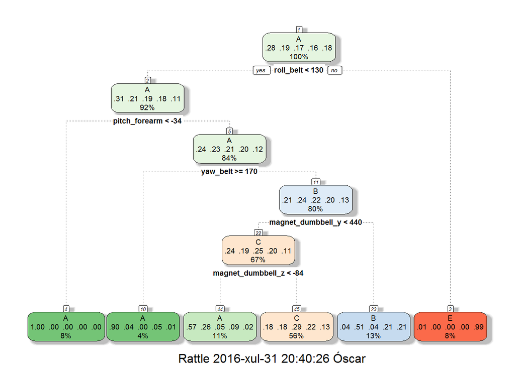

```r
train_control<- trainControl(method="cv", number=10, savePredictions = TRUE)
model2<- train(classe~., data=training, trControl=train_control, method="rpart")
fancyRpartPlot(model2$finalModel)
```

```r
pred=predict(model2,newdata=testing)
z=confusionMatrix(pred,testing$classe)
z$table
```

```
##           Reference
## Prediction    A    B    C    D    E
##          A 1390  248   36   76   22
##          B   26  508   43  244  166
##          C  809  762 1289  966  574
##          D    0    0    0    0    0
##          E    7    0    0    0  680
```

```r
z$overall[1]
```

```
##  Accuracy
## 0.4928626
```

We get the same accuracy than in the previous model.

## Random Forest Method

We use now random forest, with and without cross validation, to get a better accuracy of classification.

```r
model3=randomForest(classe~., data=training, method='class')
pred=predict(model3,testing,type='class')
```

```r
z2=confusionMatrix(pred,testing$classe)
z2$table
```

```
##           Reference
## Prediction    A    B    C    D    E
##          A 2232   15    0    0    0
##          B    0 1497   10    0    0
##          C    0    6 1358   22    0
##          D    0    0    0 1263    4
##          E    0    0    0    1 1438
```

```r
z2$overall[1]
```

```
##  Accuracy
## 0.9926077
```

This model provides 99% accurancy hence this model has been choosen to do predict the testing data set. We can check the useful of cross validation to improve the model before go to the new dataset.

```r
train_control<- trainControl(method="cv", number=10, savePredictions = TRUE)
model4=randomForest(classe~.,trControl=train_control,data=training, method='class')
```

```r
pred= predict(model4,testing,type='class')
z2=confusionMatrix(pred,testing$classe)
z2$table
```

```
##           Reference
## Prediction    A    B    C    D    E
##          A 2232   12    0    0    0
##          B    0 1502    9    0    0
##          C    0    4 1358   24    0
##          D    0    0    1 1261    4
##          E    0    0    0    1 1438
```

```r
z2$overall[1]
```

```
##  Accuracy
## 0.9929901
```

## Conclusion

I can conclude that for this data, the best model is a random forest, and the cross validation do not give to us a better fit.

## Solution to the FINAL QUIZ

```r
prediction=predict(model3,testin,type='class')
nofiles = length(prediction)
for (i in 1:nofiles){
  filename =  paste0("problem_id",i,".txt")
  write.table(prediction[i],file=filename,quote=FALSE,row.names=FALSE,col.names=FALSE)
}
prediction
```

```
##  1  2  3  4  5  6  7  8  9 10 11 12 13 14 15 16 17 18 19 20
##  B  A  B  A  A  E  D  B  A  A  B  C  B  A  E  E  A  B  B  B
## Levels: A B C D E
```